# phylogeo: geographic data on top of phylogeo

### Now we need a pretend taxonomy table

The taxonomy table lets you assign taxonomic information for each OTU. The rownames of the taxonomy table must be the same as the OTU table. Each of the columns represent some value, typically corresponding to the classic Kindom, Phylum…. Species heirarchy. However, this table can be used to assign arbitrary data to OTUs as well. Here we will generate some random taxonomy data using classic phylogeny, but with some made-up, filler data.

```r
taxmat = matrix(sample(letters, 70, replace = TRUE),
                nrow = nrow(otumat),
                ncol = 7)
rownames(taxmat) <- rownames(otumat)
colnames(taxmat) <- c("Domain", "Phylum", "Class", "Order",
                      "Family", "Genus", "Species")
taxmat
```

```
#>         Domain Phylum Class Order Family Genus Species
#> No305   "o"    "b"    "l"   "r"   "l"    "y"   "v"
#> No304   "f"    "d"    "j"   "h"   "l"    "b"   "j"
#> No306   "m"    "s"    "u"   "m"   "j"    "w"   "o"
#> No0906S "p"    "u"    "r"   "x"   "q"    "z"   "u"
#> No0908S "d"    "g"    "o"   "c"   "l"    "p"   "n"
#> No0909S "y"    "v"    "s"   "y"   "l"    "f"   "p"
#> No0910S "b"    "j"    "n"   "y"   "b"    "t"   "g"
#> No0912S "w"    "o"    "b"   "u"   "v"    "t"   "t"
#> No0913S "z"    "u"    "j"   "s"   "f"    "n"   "s"
#> No1103S "p"    "n"    "j"   "q"   "t"    "w"   "b"
#> No1007S "f"    "p"    "v"   "q"   "o"    "b"   "l"
#> No1114S "t"    "g"    "c"   "x"   "f"    "d"   "j"
#> No1202S "t"    "t"    "s"   "t"   "m"    "s"   "u"
#> No1206S "n"    "s"    "e"   "f"   "p"    "u"   "r"
#> No1208S "w"    "b"    "f"   "i"   "d"    "g"   "o"
```

### And some fake Sample Data

Sample data is information about your samples. The sample data rownames must corresond to the values in the OTU table. We will make some smaple data with some arbitrary columns. These columns are often used to store informaiton about sample processing, or about the samples themselves.

```r
sampledata <- matrix(sample(letters,samplenum*7, replace=TRUE),
                     nrow = samplenum,
                     ncol = 7)
rownames(sampledata) <- samplenames
# in your real data these columns might hold soil data, or processing information
colnames(sampledata) <- paste0("Category", 1:ncol(sampledata))
# generate some random lat and lon data and add it to the smaple data.
lat = sample((-90:90), samplenum)
lon = sample((-180:180), samplenum)
sampledata <- cbind(sampledata, lat, lon)
sampledata <- as.data.frame(sampledata)
sampledata
```

```
#>          Category1 Category2 Category3 Category4 Category5 Category6
#> Sample1          b         u         w         o         j         l
#> Sample2          d         d         i         i         x         f
#> Sample3          q         v         c         w         t         b
#> Sample4          d         n         x         h         c         s
#> Sample5          x         r         x         t         k         l
#> Sample6          d         c         u         o         f         y
#> Sample7          t         b         a         t         c         k
#> Sample8          e         f         y         w         w         c
#> Sample9          k         y         e         b         j         c
#> Sample10         s         m         j         j         x         g
#> Sample11         x         h         o         r         b         x
#> Sample12         a         b         c         z         t         o
#> Sample13         f         i         s         i         x         a
#> Sample14         q         o         j         x         s         l
#> Sample15         l         v         q         s         o         w
#>          Category7 lat  lon
#> Sample1          o  57  118
#> Sample2          b  20 -170
#> Sample3          p -46   93
#> Sample4          o  73  151
#> Sample5          v  40  178
#> Sample6          z -78   21
#> Sample7          v  22   51
#> Sample8          g -83 -153
#> Sample9          z  16 -129
#> Sample10         l  27 -157
#> Sample11         a -30  -22
#> Sample12         b -14   92
#> Sample13         a -17   55
#> Sample14         p -12 -102
#> Sample15         r  -5  -84
```

### make a phylogenetic tree from the woodhouse sequences

To take advantage of the information stored in the DNA sequences we need to generate a phylogenetic tree. Once generated and loaded into the physeq object, phylogeo can use to explore whether there are geogrphic trends in the subclades. The members of the tree must be the same names as the names of the rows (OTUs) in the OTU table.

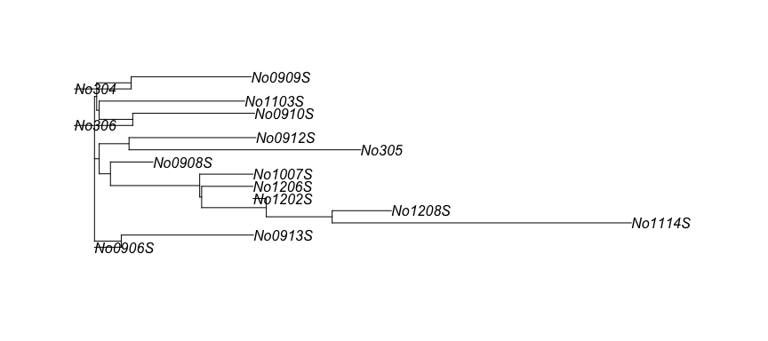

```r
#muscle is an APE wrapper for the muscle program
musc <- muscle(woodmouse)
tree <- nj(musc)
plot(tree)
```

### create the phyloseq object

All of the pieces now must be put together into the phyloseq pbject

```r
phy <- phyloseq(sample_data = sample_data(sampledata),
                otu_table   = otu_table(otumat, taxa_are_rows=TRUE),
                tax_table   = tax_table(taxmat),
                phy_tree    = phy_tree(tree))
phy
```

```
#> phyloseq-class experiment-level object
#> otu_table()   OTU Table:         [ 15 taxa and 15 samples ]
#> sample_data() Sample Data:       [ 15 samples by 9 sample variables ]
#> tax_table()   Taxonomy Table:    [ 15 taxa by 7 taxonomic ranks ]
#> phy_tree()    Phylogenetic Tree: [ 15 tips and 13 internal nodes ]
```

#### Phylogeo can now be used to map this phyloseq object.

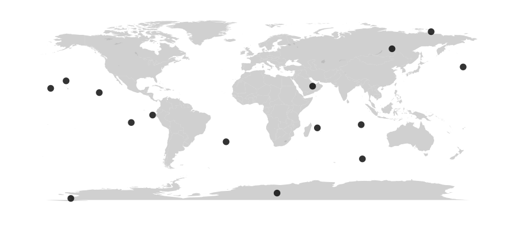

```r
# map the locations
# random lat/lons yield samples all over
map_phyloseq(phy)
```

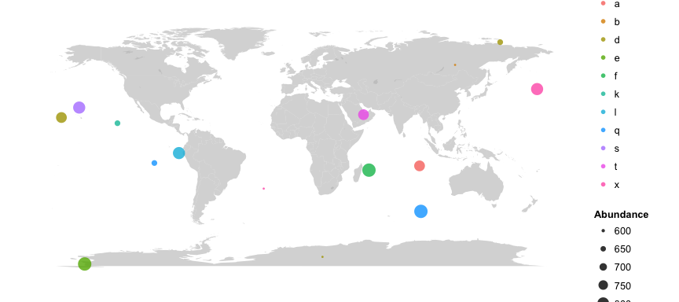

```r
# map the locations
# color by sample data category; size by abundance
map_phyloseq(phy, color="Category1", size="Abundance")
```

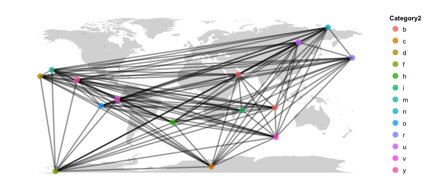

```r
# map the relationship between samples
map_network(phy, color="Category2", lines=TRUE)
```

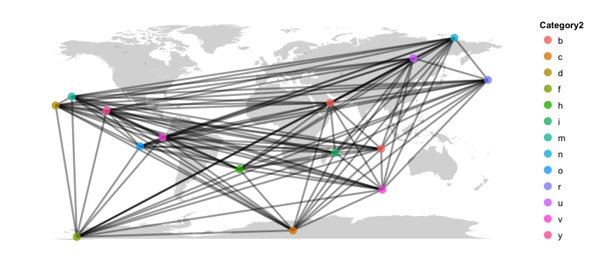

```r
# map the relationship between samples
map_network(phy, color="Category2", lines=TRUE)
```

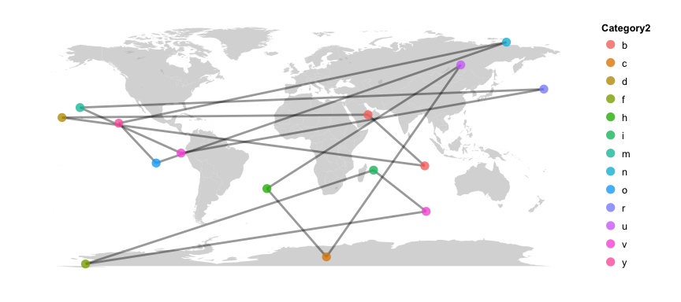

```r
# only keep highly related samples
# tip: if there are unrelated samples that drop out of the network analysis try  base_data = TRUE
map_network(phy, color="Category2",lines=TRUE, maxdist = 0.3)
```

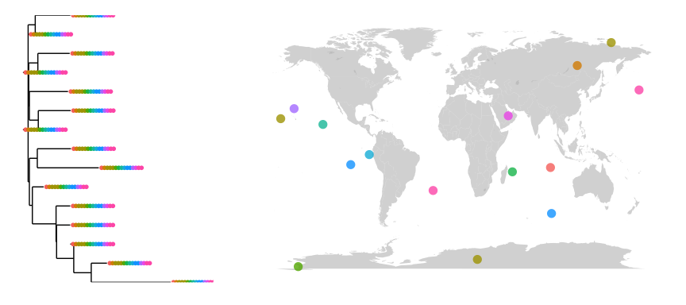

```r
# map the tree
# with this random data, perhaps it is not surprisign to wind all of the woodmouse sequences in each of the smapel locations.
map_tree(phy, color="Category1")
```

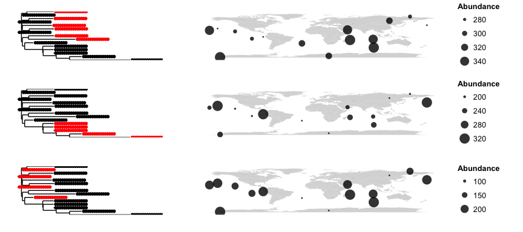

```r
# map clusters
# cluster analyses can let you look at the possilbity of non random distributions of subclades.
# does, say,  a certain subclade only occur in North America?
map_clusters(phy)
```

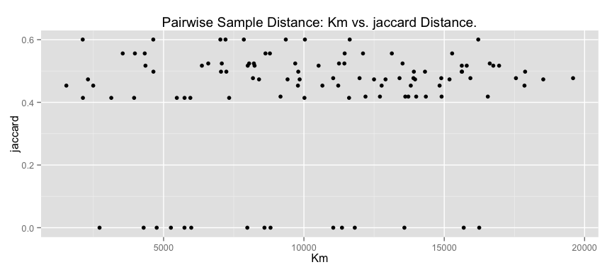

```r
# plot distance
# pairwise sample distances ecological distance vs. geographic distance
plot_distance(phy)
```